# Problem 1

Author

Putri Nisrina Az-Zahra - M0501241050

Demand Forecasting

It is a meal delivery company which operates in multiple cities. They have various fulfillment centers in these cities for dispatching meal orders to their customers. The client wants you to help these centers with demand forecasting for upcoming weeks so that these centers will plan the stock of raw materials accordingly.

Goals : **Predict the demand for the next 10 weeks** (Weeks: 136-145) for the center-meal combinations in the test set ; Forecasting accurately number of order (num_order)

```r
# Mengatur working directory
setwd("E:\\S2 IPB\\SEMESTER 2\\Pembelajaran Mesin Statistika\\Praktikum\\Problem 1")
```

## Load Library

```r
library(readxl)      # Membaca file Excel
library(skimr)       # Ringkasan statistik eksploratif
library(ggplot2)     # Visualisasi data berbasis grammar of graphics
library(tidyverse)   # Kumpulan paket untuk manipulasi & analisis data
library(reshape2)    # Transformasi format data (wide ↔ long)
library(corrplot)    # Visualisasi matriks korelasi
library(gridExtra)   # Menggabungkan beberapa plot dalam satu grid
library(caret)       # Pemrosesan data & validasi model
library(data.table)  # Manipulasi data skala besar
library(lightgbm)    # Model Gradient Boosting yang cepat
library(xgboost)     # Model Extreme Gradient Boosting
library(Matrix)      # Operasi matriks efisien
library(randomForest)# Algoritma Random Forest
library(fastDummies) # Pembuatan variabel dummy cepat
```

## Load Data

### Train

```r
train <- read_xlsx("train.xlsx")
head(train)
```

```
# A tibble: 6 × 9
      id  week center_id meal_id checkout_price base_price emailer_for_promotion
   <dbl> <dbl>     <dbl>   <dbl>          <dbl>      <dbl>                 <dbl>
1 1.38e6     1        55    1885           137.       152.                     0
2 1.47e6     1        55    1993           137.       136.                     0
3 1.35e6     1        55    2539           135.       136.                     0
4 1.34e6     1        55    2139           340.       438.                     0
5 1.45e6     1        55    2631           244.       242.                     0
6 1.27e6     1        55    1248           251.       252.                     0
# ℹ 2 more variables: homepage_featured <dbl>, num_orders <dbl>
```

### Test

```r
test <- read_xlsx("test.xlsx")
head(test)
```

```
# A tibble: 6 × 8
      id  week center_id meal_id checkout_price base_price emailer_for_promotion
   <dbl> <dbl>     <dbl>   <dbl>          <dbl>      <dbl>                 <dbl>
1 1.02e6   136        55    1885          148.        148.                     0
2 1.40e6   136        55    1993          151.        151.                     0
3 1.01e6   136        55    2539          152.        151.                     0
4 1.04e6   136        55    2631           96.0       166.                     0
5 1.02e6   136        55    1248           97         166.                     0
6 1.19e6   136        55    1778          165.        165.                     0
# ℹ 1 more variable: homepage_featured <dbl>
```

### Meal Info

```r
meal_info <- read.csv("meal_info.csv")
head(meal_info)
```

```
  meal_id  category cuisine
1    1885 Beverages    Thai
2    1993 Beverages    Thai
3    2539 Beverages    Thai
4    1248 Beverages  Indian
5    2631 Beverages  Indian
6    1311    Extras    Thai
```

### Fulfilment Center Info

```r
fulfilment_center_info <- read.csv("fulfilment_center_info.csv")
head(fulfilment_center_info)
```

```
  center_id city_code region_code center_type op_area
1        11       679          56      TYPE_A     3.7
2        13       590          56      TYPE_B     6.7
3       124       590          56      TYPE_C     4.0
4        66       648          34      TYPE_A     4.1
5        94       632          34      TYPE_C     3.6
6        64       553          77      TYPE_A     4.4
```

## Pre-Processing Data

### Added Meal Info

```r
# Join Data Meal Info by meal_id
train <- train %>%
  left_join(meal_info, by = "meal_id")

head(train)
```

```
# A tibble: 6 × 11
      id  week center_id meal_id checkout_price base_price emailer_for_promotion
   <dbl> <dbl>     <dbl>   <dbl>          <dbl>      <dbl>                 <dbl>
1 1.38e6     1        55    1885           137.       152.                     0
2 1.47e6     1        55    1993           137.       136.                     0
3 1.35e6     1        55    2539           135.       136.                     0
4 1.34e6     1        55    2139           340.       438.                     0
5 1.45e6     1        55    2631           244.       242.                     0
6 1.27e6     1        55    1248           251.       252.                     0
# ℹ 4 more variables: homepage_featured <dbl>, num_orders <dbl>,
#   category <chr>, cuisine <chr>
```

### Added Fulfillment Center Info

```r
# Join Data Fulfillment Center Info by center_id
train <- train %>%
  left_join(fulfilment_center_info, by = "center_id")

head(train)
```

```
# A tibble: 6 × 15
      id  week center_id meal_id checkout_price base_price emailer_for_promotion
   <dbl> <dbl>     <dbl>   <dbl>          <dbl>      <dbl>                 <dbl>
1 1.38e6     1        55    1885           137.       152.                     0
2 1.47e6     1        55    1993           137.       136.                     0
3 1.35e6     1        55    2539           135.       136.                     0
4 1.34e6     1        55    2139           340.       438.                     0
5 1.45e6     1        55    2631           244.       242.                     0
6 1.27e6     1        55    1248           251.       252.                     0
# ℹ 8 more variables: homepage_featured <dbl>, num_orders <dbl>,
#   category <chr>, cuisine <chr>, city_code <int>, region_code <int>,
#   center_type <chr>, op_area <dbl>
```

### Updated Data

```r
# Melihat Struktur Data
str(train)
```

```
tibble [456,548 × 15] (S3: tbl_df/tbl/data.frame)
 $ id                   : num [1:456548] 1379560 1466964 1346989 1338232 1448490 ...
 $ week                 : num [1:456548] 1 1 1 1 1 1 1 1 1 1 ...
 $ center_id            : num [1:456548] 55 55 55 55 55 55 55 55 55 55 ...
 $ meal_id              : num [1:456548] 1885 1993 2539 2139 2631 ...
 $ checkout_price       : num [1:456548] 137 137 135 340 244 ...
 $ base_price           : num [1:456548] 152 136 136 438 242 ...
 $ emailer_for_promotion: num [1:456548] 0 0 0 0 0 0 0 0 0 0 ...
 $ homepage_featured    : num [1:456548] 0 0 0 0 0 0 0 0 0 1 ...
 $ num_orders           : num [1:456548] 177 270 189 54 40 28 190 391 472 676 ...
 $ category             : chr [1:456548] "Beverages" "Beverages" "Beverages" "Beverages" ...
 $ cuisine              : chr [1:456548] "Thai" "Thai" "Thai" "Indian" ...
 $ city_code            : int [1:456548] 647 647 647 647 647 647 647 647 647 647 ...
 $ region_code          : int [1:456548] 56 56 56 56 56 56 56 56 56 56 ...
 $ center_type          : chr [1:456548] "TYPE_C" "TYPE_C" "TYPE_C" "TYPE_C" ...
 $ op_area              : num [1:456548] 2 2 2 2 2 2 2 2 2 2 ...
```

- `id`: ID unik untuk setiap data.
- `week`: Periode waktu pemesanan makanan.
- `center_id`: ID pusat distribusi makanan.
- `meal_id`: ID makanan yang ditawarkan.
- `checkout_price`: Harga akhir makanan yang dibayar pelanggan setelah diskon.
- `base_price`: Harga awal makanan sebelum diskon.
- `emailer_for_promotion`: Indikator apakah makanan dipromosikan melalui email (0 = tidak, 1 = ya).
- `homepage_featured`: Indikator apakah makanan ditampilkan di halaman utama untuk promosi (0 = tidak, 1 = ya).
- `num_orders`: Jumlah pesanan makanan dan berperan sebagai variabel target.
- `category`: Kategori makanan atau minuman.
- `cuisine`: Jenis masakan berdasarkan gaya kuliner.
- `city_code`: Kode kota tempat pusat distribusi berada.
- `region_code`: Kode wilayah tempat pusat distribusi berada.
- `center_type`: Jenis pusat distribusi makanan.
- `op_area`: Luas operasional pusat distribusi dalam satuan tertentu.

```r
# Mengecek Missing Value pada data train
any(is.na(train))
```

```
[1] FALSE
```

Tidak ada variabel yang memiliki missing value (NA) pada data train sehingga tidak perlu dilakukan penanganan seperti imputasi atau penghapusan baris/kolom dengan nilai NA.

```r
# Split Data as Validation
test_validation <- train %>% filter((week >= 136 & week <= 145))
glimpse(test_validation)
```

```
Rows: 32,821
Columns: 15
$ id                    <dbl> 1017495, 1395634, 1007493, 1042952, 1022147, 119…
$ week                  <dbl> 136, 136, 136, 136, 136, 136, 136, 136, 136, 136…
$ center_id             <dbl> 55, 55, 55, 55, 55, 55, 55, 55, 55, 55, 55, 55, …
$ meal_id               <dbl> 1885, 1993, 2539, 2631, 1248, 1778, 1062, 2707, …
$ checkout_price        <dbl> 148.44, 151.38, 152.35, 96.03, 97.00, 164.90, 17…
$ base_price            <dbl> 148.44, 151.38, 151.35, 165.93, 165.93, 164.90, …
$ emailer_for_promotion <dbl> 0, 0, 0, 0, 0, 0, 0, 0, 0, 0, 0, 0, 1, 0, 0, 0, …
$ homepage_featured     <dbl> 0, 0, 0, 0, 0, 0, 0, 0, 1, 0, 1, 0, 1, 0, 0, 0, …
$ num_orders            <dbl> 134, 216, 163, 95, 14, 136, 310, 95, 230, 134, 1…
$ category              <chr> "Beverages", "Beverages", "Beverages", "Beverage…
$ cuisine               <chr> "Thai", "Thai", "Thai", "Indian", "Indian", "Ita…
$ city_code             <int> 647, 647, 647, 647, 647, 647, 647, 647, 647, 647…
$ region_code           <int> 56, 56, 56, 56, 56, 56, 56, 56, 56, 56, 56, 56, …
$ center_type           <chr> "TYPE_C", "TYPE_C", "TYPE_C", "TYPE_C", "TYPE_C"…
$ op_area               <dbl> 2, 2, 2, 2, 2, 2, 2, 2, 2, 2, 2, 2, 2, 2, 2, 2, …
```

Data train dengan minggu ke-136 sampai minggu ke-145 digunakan untuk validasi jumlah num_orders dari hasil prediksi model yaitu sebanyak 32.821 baris data.

```r
# Data Week 1 - 135
train <- train %>% filter(!(week >= 136 & week <= 145))
glimpse(train)
```

```
Rows: 423,727
Columns: 15
$ id                    <dbl> 1379560, 1466964, 1346989, 1338232, 1448490, 127…
$ week                  <dbl> 1, 1, 1, 1, 1, 1, 1, 1, 1, 1, 1, 1, 1, 1, 1, 1, …
$ center_id             <dbl> 55, 55, 55, 55, 55, 55, 55, 55, 55, 55, 55, 55, …
$ meal_id               <dbl> 1885, 1993, 2539, 2139, 2631, 1248, 1778, 1062, …
$ checkout_price        <dbl> 136.83, 136.83, 134.86, 339.50, 243.50, 251.23, …
$ base_price            <dbl> 152.29, 135.83, 135.86, 437.53, 242.50, 252.23, …
$ emailer_for_promotion <dbl> 0, 0, 0, 0, 0, 0, 0, 0, 0, 0, 0, 0, 0, 0, 1, 0, …
$ homepage_featured     <dbl> 0, 0, 0, 0, 0, 0, 0, 0, 0, 1, 1, 1, 0, 0, 0, 0, …
$ num_orders            <dbl> 177, 270, 189, 54, 40, 28, 190, 391, 472, 676, 8…
$ category              <chr> "Beverages", "Beverages", "Beverages", "Beverage…
$ cuisine               <chr> "Thai", "Thai", "Thai", "Indian", "Indian", "Ind…
$ city_code             <int> 647, 647, 647, 647, 647, 647, 647, 647, 647, 647…
$ region_code           <int> 56, 56, 56, 56, 56, 56, 56, 56, 56, 56, 56, 56, …
$ center_type           <chr> "TYPE_C", "TYPE_C", "TYPE_C", "TYPE_C", "TYPE_C"…
$ op_area               <dbl> 2, 2, 2, 2, 2, 2, 2, 2, 2, 2, 2, 2, 2, 2, 2, 2, …
```

Data train dengan minggu ke-1 sampai minggu ke-135 sebanyak 423.727 baris dan 15 kolom digunakan untuk melatih model yang dapat memprediksi variabel num_orders atau jumlah pesanan makanan.

## Exploration Data

### Summary Data

```r
skim_without_charts(train)
```

Data summary

| Name | train |
| --- | --- |
| Number of rows | 423727 |
| Number of columns | 15 |
| _______________________ |  |
| Column type frequency: |  |
| character | 3 |
| numeric | 12 |
| ________________________ |  |
| Group variables | None |

**Variable type: character**

| skim_variable | n_missing | complete_rate | min | max | empty | n_unique | whitespace |
| --- | --- | --- | --- | --- | --- | --- | --- |
| category | 0 | 1 | 4 | 12 | 0 | 14 | 0 |
| cuisine | 0 | 1 | 4 | 11 | 0 | 4 | 0 |
| center_type | 0 | 1 | 6 | 6 | 0 | 3 | 0 |

**Variable type: numeric**

| skim_variable | n_missing | complete_rate | mean | sd | p0 | p25 | p50 | p75 | p100 |
| --- | --- | --- | --- | --- | --- | --- | --- | --- | --- |
| id | 0 | 1 | 1249964.44 | 144343.12 | 1.000e+06 | 1124878.50 | 1249955.00 | 1374949.00 | 1499999.00 |
| week | 0 | 1 | 69.68 | 38.69 | 1.000e+00 | 37.00 | 70.00 | 103.00 | 135.00 |
| center_id | 0 | 1 | 82.11 | 45.98 | 1.000e+01 | 43.00 | 76.00 | 110.00 | 186.00 |
| meal_id | 0 | 1 | 2023.96 | 547.37 | 1.062e+03 | 1558.00 | 1971.00 | 2539.00 | 2956.00 |
| checkout_price | 0 | 1 | 331.53 | 153.09 | 2.970e+00 | 228.01 | 292.03 | 444.29 | 866.27 |
| base_price | 0 | 1 | 353.73 | 160.92 | 5.535e+01 | 243.50 | 309.49 | 458.87 | 866.27 |
| emailer_for_promotion | 0 | 1 | 0.08 | 0.28 | 0.000e+00 | 0.00 | 0.00 | 0.00 | 1.00 |
| homepage_featured | 0 | 1 | 0.11 | 0.31 | 0.000e+00 | 0.00 | 0.00 | 0.00 | 1.00 |
| num_orders | 0 | 1 | 264.55 | 403.57 | 1.300e+01 | 54.00 | 136.00 | 324.00 | 24299.00 |
| city_code | 0 | 1 | 601.56 | 66.21 | 4.560e+02 | 553.00 | 596.00 | 651.00 | 713.00 |
| region_code | 0 | 1 | 56.61 | 17.64 | 2.300e+01 | 34.00 | 56.00 | 77.00 | 93.00 |
| op_area | 0 | 1 | 4.08 | 1.09 | 9.000e-01 | 3.60 | 4.00 | 4.50 | 7.00 |

### Check Duplicated Data

```r
# Mengecek duplikasi data
sum(duplicated(train))
```

```
[1] 0
```

Tidak ada data yang duplikat pada data train sehingga tidak perlu dilakukan penghapusan baris data yang duplikat.

### Num of Order

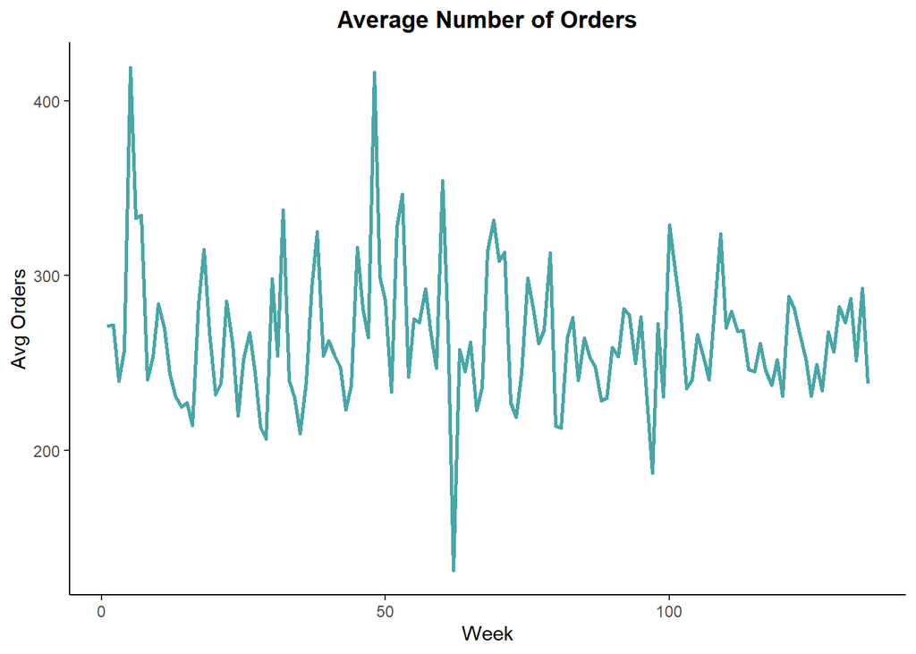

```r
train_filtered <- train %>%
  group_by(week) %>%
  summarize(avg_orders = mean(num_orders, na.rm = TRUE))

ggplot(train_filtered, aes(x = week, y = avg_orders)) +
  geom_line(color = "#48A6A7", linewidth = 1) +
  labs(title = "Average Number of Orders", x = "Week", y = "Avg Orders") +
  theme_classic() +
  theme(
    plot.title = element_text(hjust = 0.5, face = "bold")
  )
```

Plot deret waktu dari `num_orders` menunjukkan **fluktuasi yang signifikan** dalam jumlah pesanan makanan per minggu, dengan beberapa lonjakan tajam yang kemungkinan dipengaruhi oleh promosi atau faktor musiman. Sebaliknya, terdapat pula penurunan drastis pada beberapa titik. Pola ini menunjukkan kemungkinan **adanya siklus permintaan yang berulang**, meskipun di bagian akhir grafik tren tampak lebih stabil.

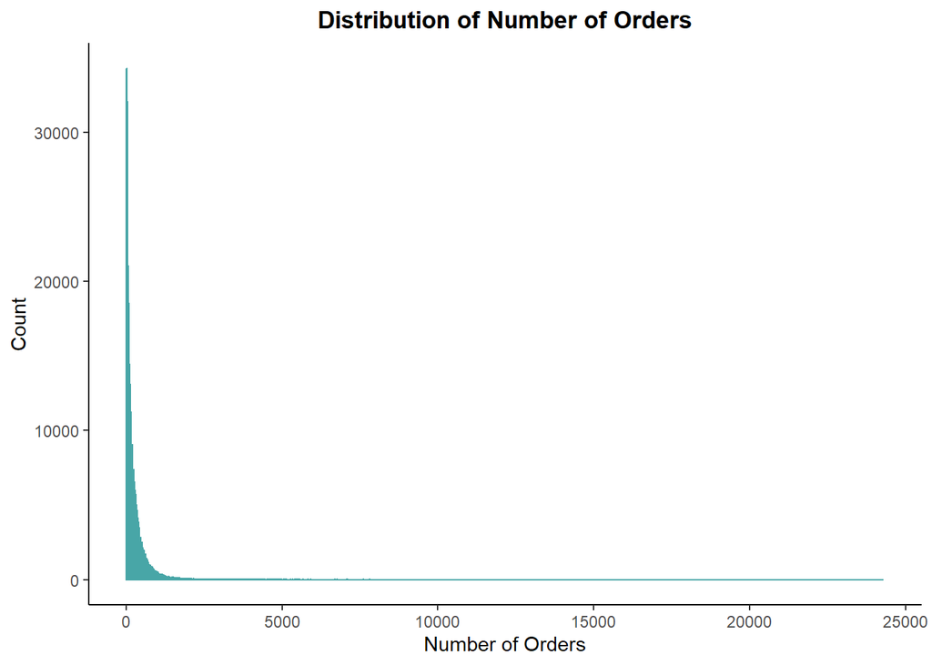

```r
ggplot(train, aes(x = num_orders)) +
  geom_histogram(binwidth = 10, fill = "#48A6A7", color = "#48A6A7", alpha = 0.8) +
  labs(title = "Distribution of Number of Orders", x = "Number of Orders", y = "Count") +
  theme_classic() +
  theme(
    plot.title = element_text(hjust = 0.5, face = "bold")
  )
```

Plot ini menunjukkan distribusi jumlah pesanan makanan dengan sebagian besar pesanan berada pada nilai yang relatif kecil. Sebagian besar **jumlah pesanan terkonsentrasi di sekitar nol** hingga beberapa ratus pesanan, sementara ada beberapa outlier dengan jumlah pesanan yang jauh lebih tinggi, bahkan mendekati 25.000. Distribusi ini mengindikasikan bahwa sebagian besar makanan memiliki permintaan yang rendah hingga sedang, sementara hanya sedikit yang memiliki permintaan sangat tinggi.

## Feature

### Density Plot of Numeric Feature

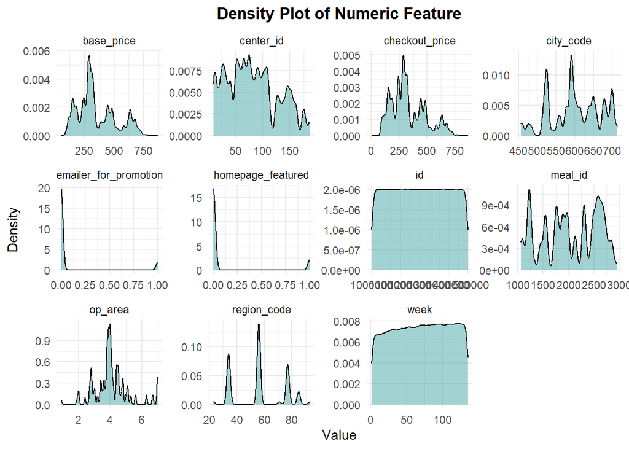

```r
train %>%
  select(-num_orders) %>%
  select(where(is.numeric)) %>%
  pivot_longer(cols = everything(), names_to = "variable", values_to = "value") %>%
  ggplot(aes(x = value)) +
  facet_wrap(~ variable, scales = "free") +
  geom_density(fill = "#48A6A7", alpha = 0.5) +
  labs(
    title = "Density Plot of Numeric Feature",
    x = "Value",
    y = "Density"
  ) +
  theme_minimal() +
  theme(
    plot.title = element_text(hjust = 0.5, face = "bold")
  )
```

### Boxplot of Numeric Feature

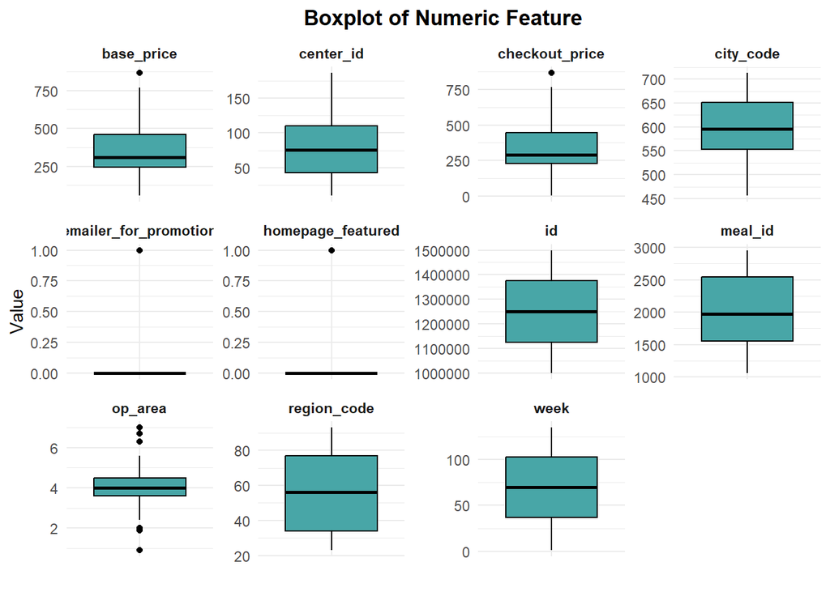

```r
train %>%
  select(-num_orders) %>%
  select(where(is.numeric)) %>%
  pivot_longer(cols = everything(), names_to = "variable", values_to = "value") %>%
  ggplot(aes(x = "", y = value)) +
  geom_boxplot(fill = "#48A6A7", color = "black") +
  theme_minimal() +
  labs(title = "Boxplot of Numeric Feature",
       x = "",
       y = "Value") +
  facet_wrap(~ variable, scales = "free", ncol = 4) +
  theme(
    axis.text.x = element_blank(),
    axis.ticks.x = element_blank(),
    strip.text = element_text(face = "bold"),
    plot.title = element_text(hjust = 0.5, face = "bold")
  )
```

- `base_price` dan `checkout_price` : memiliki distribusi dengan beberapa pencilan (outlier) di bagian atas, menunjukkan adanya beberapa harga yang jauh lebih tinggi dibandingkan mayoritas data.
- `emailer_for_promotion` dan `homepage_featured` : memiliki distribusi yang sangat tidak merata dengan dominasi nilai nol, tetapi ada beberapa pencilan yang menunjukkan bahwa hanya sebagian kecil data yang memiliki nilai 1.
- `op_area` : menunjukkan beberapa outlier, baik di bagian bawah maupun atas, menandakan variasi yang cukup besar dalam area operasional.
- `id`, `meal_id`, `region_code`, dan `week` : memiliki distribusi yang lebih merata tanpa outlier signifikan, menunjukkan bahwa data pada fitur ini tersebar secara konsisten dalam rentangnya.
- `center_id` dan `city_code` : menunjukkan distribusi yang cukup lebar tetapi tidak memiliki pencilan signifikan, menandakan bahwa pusat distribusi dan kode kota tersebar dalam kisaran yang cukup stabil.

### Correlation between num_orders and Numeric Features

```r
correlations <- train %>%
  select(num_orders, where(is.numeric)) %>%
  cor(use = "complete.obs")

correlations_num_orders <- correlations["num_orders", -1]

correlations_table <- data.frame(
  Variable = names(correlations_num_orders),
  Correlation = round(as.numeric(correlations_num_orders), 3) # Pembulatan 3 desimal
)

print(correlations_table, row.names = FALSE)
```

```
              Variable Correlation
                    id       0.001
                  week      -0.007
             center_id      -0.051
               meal_id       0.012
        checkout_price      -0.283
            base_price      -0.221
 emailer_for_promotion       0.283
     homepage_featured       0.299
             city_code       0.041
           region_code       0.030
               op_area       0.174
```

Korelasi antara variabel-variabel ini dengan `num_order` relatif rendah. **Tidak ada variabel yang memiliki korelasi yang sangat kuat** (> 0.5 atau < -0.5), yang menunjukkan bahwa tidak ada satu faktor dominan yang secara langsung menentukan jumlah pesanan.

### Correlation Between Numeric Feature

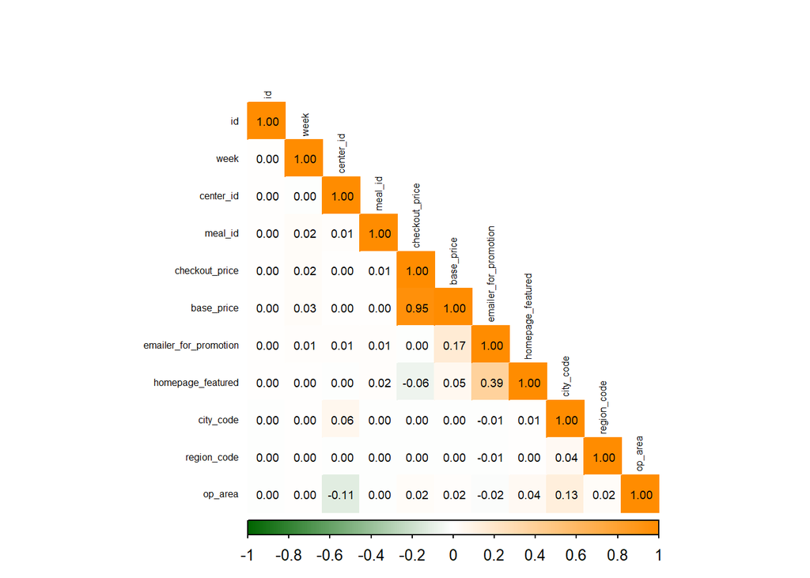

```r
numeric_vars <-
  train %>%
  select(-num_orders) %>%
  select(where(is.numeric))
correlation_matrix_pearson <- cor(numeric_vars, method = "pearson")
corrplot(correlation_matrix_pearson, method = "color", type = "lower",
         col = colorRampPalette(c("darkgreen", "white", "darkorange"))(200),
         tl.col = "black", tl.cex = 0.5,
         addCoef.col = "black", number.cex = 0.6, number.font = 0.5)
```

Plot heatmap menunjukkan bahwa s**ebagian besar variabel tidak memiliki korelasi kuat satu sama lain**. Variabel harga (`checkout_price` dan `base_price`) memiliki korelasi tinggi, yang menunjukkan **keterkaitan langsung antara harga dasar dan harga jual.**

### Distribution of Category Feature

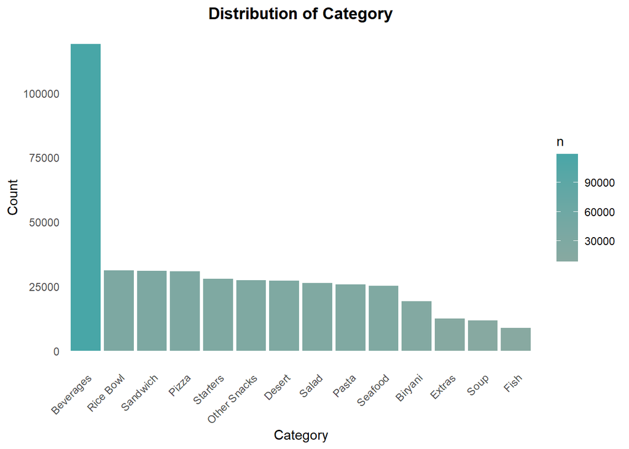

```r
category_counts <- train %>%
  count(category) %>%
  arrange(desc(n))

ggplot(category_counts, aes(x = reorder(category, -n), y = n, fill = n)) +
  geom_bar(stat = "identity") +
  theme_minimal() +
  labs(title = "Distribution of Category",
       x = "Category",
       y = "Count") +
  theme(axis.text.x = element_text(angle = 45, hjust = 1),
        panel.grid = element_blank(),
        panel.background = element_blank(),
        plot.title = element_text(hjust = 0.5, face = "bold")) +
  scale_fill_gradient(low = "#88A9A1", high = "#48A6A7")
```

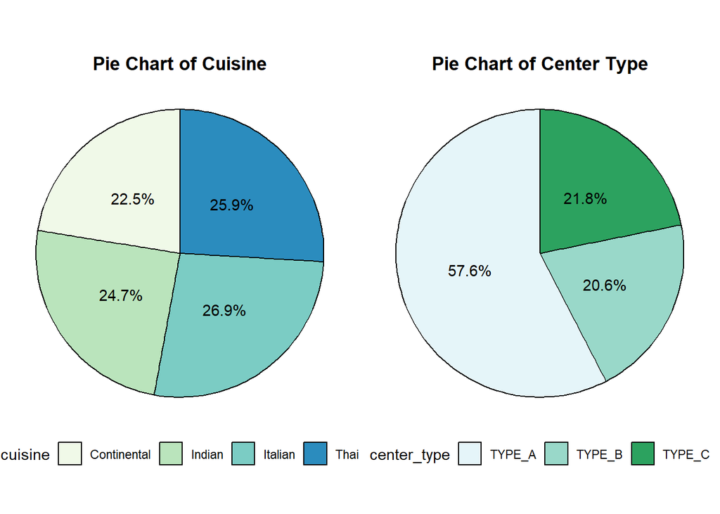

```r
category_counts <- train %>%
  count(cuisine) %>%
  mutate(percentage = n / sum(n) * 100)

p1 <- ggplot(category_counts, aes(x = "", y = n, fill = cuisine)) +
  geom_bar(stat = "identity", width = 1, color = "black") +  # Added border color
  coord_polar("y") +
  theme_void() +
  labs(title = "Pie Chart of Cuisine") +
  theme(plot.title = element_text(hjust = 0.5, face = "bold"),
         legend.position = "bottom") +
  scale_fill_brewer(palette = "GnBu") +
  geom_text(aes(label = paste0(round(percentage, 1), "%")), position = position_stack(vjust = 0.5), color = "black")

category_counts <- train %>%
  count(center_type) %>%
  mutate(percentage = n / sum(n) * 100)

p2 <- ggplot(category_counts, aes(x = "", y = n, fill = center_type)) +
  geom_bar(stat = "identity", width = 1, color = "black") +  # Added border color
  coord_polar("y") +
  theme_void() +
  labs(title = "Pie Chart of Center Type") +
  theme(plot.title = element_text(hjust = 0.5, face = "bold"),
         legend.position = "bottom") +
  scale_fill_brewer(palette = "BuGn") +
  geom_text(aes(label = paste0(round(percentage, 1), "%")), position = position_stack(vjust = 0.5), color = "black")


grid.arrange(p1, p2, ncol = 2)
```

Pada pie chart dengan variabel cuisine, terlihat bahwa **masakan Italian memiliki proporsi terbesar**, yaitu 26.9%, diikuti oleh masakan Thai sebesar 25.9%. Sementara itu, masakan Indian mencakup 24.7% dari total, dan masakan Continental memiliki proporsi terkecil dengan 22.5%.

Pada pie chart dengan variabel center_type, distribusi pusat distribusi berdasarkan jenisnya menunjukkan bahwa TYPE_A mendominasi dengan 57.6% dari total pusat distribusi, sedangkan TYPE_B dan TYPE_C masing-masing memiliki proporsi 20.6% dan 21.8%. Hal ini menunjukkan bahwa **sebagian besar operasi distribusi dikelola oleh pusat dengan tipe A**, yang kemungkinan memiliki kapasitas lebih besar atau cakupan yang lebih luas dibandingkan tipe lainnya.

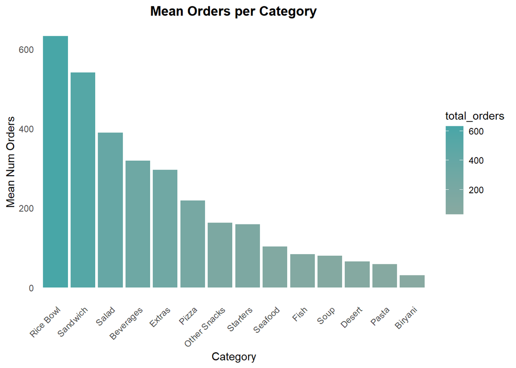

```r
category_orders <- train %>%
  group_by(category) %>%
  summarise(total_orders = mean(num_orders, na.rm = TRUE)) %>%
  arrange(desc(total_orders))

ggplot(category_orders, aes(x = reorder(category, -total_orders), y = total_orders, fill = total_orders)) +
  geom_bar(stat = "identity") +
  theme_minimal() +
  labs(title = "Mean Orders per Category",
       x = "Category",
       y = "Mean Num Orders") +
  theme(axis.text.x = element_text(angle = 45, hjust = 1),
        panel.grid = element_blank(),
        panel.background = element_blank(),
        plot.title = element_text(hjust = 0.5, face = "bold")) +
  scale_fill_gradient(low = "#88A9A1", high = "#48A6A7")
```

Pada bar plot dengan variabel `category`, kategori **Rice Bowl memiliki rata-rata pesanan tertinggi**, diikuti oleh Sandwich dan Salad, yang juga memiliki jumlah pesanan yang cukup tinggi dibandingkan kategori lainnya. Beverages dan Extras juga memiliki jumlah pesanan yang signifikan, meskipun lebih rendah dibandingkan tiga kategori teratas.

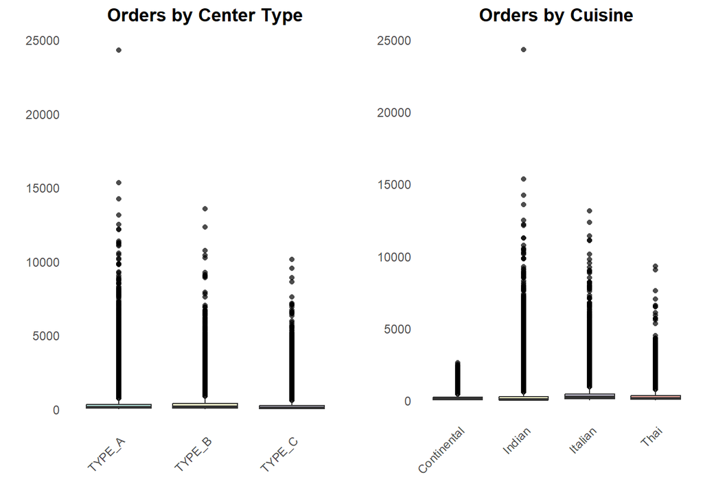

```r
p1 <- ggplot(train, aes(x = center_type, y = num_orders, fill = center_type)) +
  geom_boxplot(alpha = 0.7, outlier.color = "black", outlier.shape = 16) +
  theme_minimal() +
  labs(title = "Orders by Center Type",
       x = "",
       y = "") +
  theme(axis.text.x = element_text(angle = 45, hjust = 1),
        panel.grid = element_blank(),
        panel.background = element_blank(),
        legend.position = "none",
        plot.title = element_text(hjust = 0.5, face = "bold")) +
  scale_fill_brewer(palette = "Set3")

p2 <- ggplot(train, aes(x = cuisine, y = num_orders, fill = cuisine)) +
  geom_boxplot(alpha = 0.7, outlier.color = "black", outlier.shape = 16) +
  theme_minimal() +
  labs(title = "Orders by Cuisine",
       x = "",
       y = "") +
  theme(axis.text.x = element_text(angle = 45, hjust = 1),
        panel.grid = element_blank(),
        panel.background = element_blank(),
        legend.position = "none",
        plot.title = element_text(hjust = 0.5, face = "bold")) +
  scale_fill_brewer(palette = "Set3")

grid.arrange(p1, p2, ncol = 2)
```

Pada Boxplot Orders by Center Type, terdapat tiga kategori pusat distribusi, yaitu TYPE_A, TYPE_B, dan TYPE_C. M**asing-masing kategori memiliki persebaran jumlah pesanan yang cukup mirip**, dengan banyak outlier yang menunjukkan bahwa beberapa pusat distribusi memiliki pesanan yang jauh lebih tinggi dibandingkan mayoritas lainnya.

Pada Boxplot Orders by Cuisine, terdapat empat kategori masakan yaitu Continental, Indian, Italian, dan Thai. **Pola persebarannya juga menunjukkan bahwa sebagian besar pesanan berada di kisaran rendah**, namun terdapat beberapa outlier dengan jumlah pesanan yang sangat tinggi, terutama pada masakan Indian dan Italian.

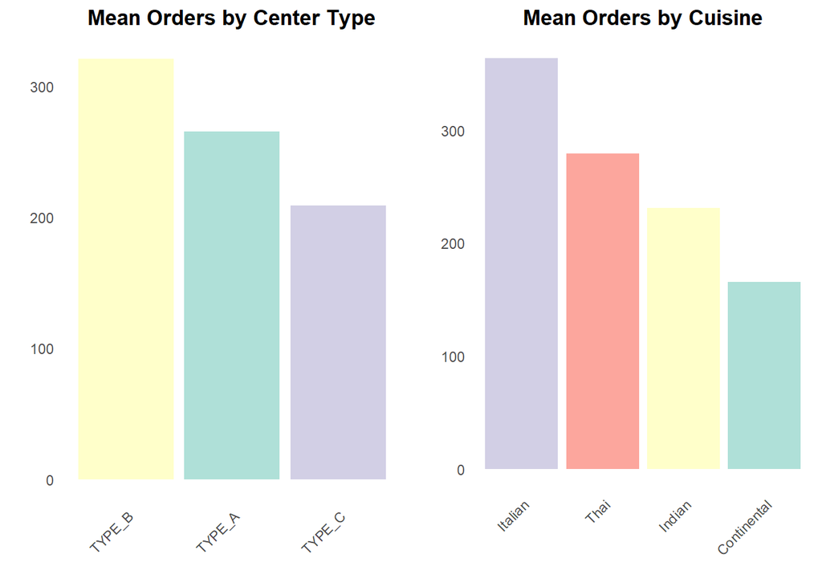

```r
center_orders <- train %>%
  group_by(center_type) %>%
  summarise(total_orders = mean(num_orders, na.rm = TRUE)) %>%
  arrange(desc(total_orders))

p1 <- ggplot(center_orders, aes(x = reorder(center_type, -total_orders), y = total_orders, fill = center_type)) +
  geom_bar(stat = "identity", alpha = 0.7) +
  theme_minimal() +
  labs(title = "Mean Orders by Center Type",
       x = "",
       y = "") +
  theme(axis.text.x = element_text(angle = 45, hjust = 1),
        panel.grid = element_blank(),
        panel.background = element_blank(),
        legend.position = "none",
        plot.title = element_text(hjust = 0.5, face = "bold")) +
  scale_fill_brewer(palette = "Set3")

cuisine_data <- train %>%
  group_by(cuisine) %>%
  summarise(total_orders = mean(num_orders, na.rm = TRUE)) %>%
  arrange(desc(total_orders))

p2 <- ggplot(cuisine_data, aes(x = reorder(cuisine, -total_orders), y = total_orders, fill = cuisine)) +
  geom_bar(stat = "identity", alpha = 0.7) +
  theme_minimal() +
  labs(title = "Mean Orders by Cuisine",
       x = "",
       y = "") +
  theme(axis.text.x = element_text(angle = 45, hjust = 1),
        panel.grid = element_blank(),
        panel.background = element_blank(),
        legend.position = "none",
        plot.title = element_text(hjust = 0.5, face = "bold")) +
  scale_fill_brewer(palette = "Set3")

grid.arrange(p1, p2, ncol = 2)
```

Pada barplot Mean Orders by Center Type, menunjukkan bahwa **pusat distribusi TYPE_B memiliki rata-rata jumlah pesanan tertinggi**, diikuti oleh TYPE_A, sementara TYPE_C memiliki rata-rata terendah. Hal ini dapat mengindikasikan bahwa pusat distribusi TYPE_B lebih dominan dalam pemenuhan pesanan dibandingkan dua tipe lainnya.

Pada barplot Mean Orders by Cuisine mengilustrasikan bahwa **masakan Italian memiliki rata-rata pesanan tertinggi**, diikuti oleh Thai dan Indian, sedangkan Continental memiliki rata-rata pesanan terendah. Ini menunjukkan bahwa masakan Italian lebih populer atau memiliki permintaan yang lebih tinggi dibandingkan jenis masakan lainnya.

## Pre-Modelling

### Split Train - Test Data

Dataset train menjadi **data latih (80%) dan data uji (20%)** secara stratifikasi berdasarkan `id`. Fungsi set.seed(50) memastikan pemilihan data tetap konsisten, sementara createDataPartition() menghasilkan indeks untuk data latih. Indeks ini kemudian digunakan untuk mengekstrak data latih dan data uji dari dataset asli.

```r
set.seed(50)
train_indices <- createDataPartition(train$id, p = 0.8, list = FALSE)
train_data <- train[train_indices, ]
test_data <- train[-train_indices, ]
```

### Declare Target and Feature

Selanjutnya dilakukan pemisahan fitur dan target dalam dataset pelatihan dan pengujian. Setelah itu, data dipisahkan menjadi variabel yang berisi fitur dan variabel yang berisi target sehingga siap digunakan untuk proses pemodelan.

```r
features <- setdiff(names(train), c("id", "num_orders"))
X_train <- train_data[, features, with = FALSE]
y_train <- train_data$num_orders
X_test <- test_data[, features, with = FALSE]
y_test <- test_data$num_orders
```

### One-Hot Encoding

Data diubah menjadi format data.table, kemudian fitur kategorikal diidentifikasi dan dikonversi menjadi faktor. Selanjutnya, dilakukan **One-Hot Encoding untuk mengonversi kategori menjadi variabel biner**. Setelah itu, semua kolom dipastikan dalam bentuk numerik untuk melakukan pemodelan machine learning. Terakhir, dilakukan pengecekan untuk memastikan tidak ada nilai yang hilang (NA) dalam data yang telah diproses.

```r
# Memastikan X_train dan X_test adalah data.table
setDT(X_train)
setDT(X_test)

# Identifikasi fitur kategorikal yang valid
categorical_features <- names(X_train)[sapply(X_train, is.character)]
categorical_features <- intersect(names(X_train), categorical_features)

# Konversi fitur kategorikal menjadi faktor
X_train[, (categorical_features) := lapply(.SD, as.factor), .SDcols = categorical_features]
X_test[, (categorical_features) := lapply(.SD, as.factor), .SDcols = categorical_features]

# Pastikan categorical_features hanya berisi fitur yang ada di X_train_final
setdiff(categorical_features, names(X_train))
```

```
character(0)
```

```r
# One-Hot Encoding untuk fitur kategorikal pada X_train dan X_test
X_train_encoded <- dummy_cols(X_train, select_columns = categorical_features, remove_first_dummy = TRUE)
X_test_encoded <- dummy_cols(X_test, select_columns = categorical_features, remove_first_dummy = TRUE)

# Pisahkan kembali target (num_orders)
X_train_final <- X_train_encoded[, setdiff(names(X_train_encoded), "num_orders"), with = FALSE]
X_test_final <- X_test_encoded[, setdiff(names(X_test_encoded), "num_orders"), with = FALSE]

# Pastikan semua kolom dalam data adalah numerik setelah encoding
X_train_final <- data.matrix(X_train_final)
X_test_final <- data.matrix(X_test_final)

# Konfirmasi bahwa tidak ada NA di data
sum(is.na(X_train_final))
```

```
[1] 0
```

```r
sum(is.na(X_test_final))
```

```
[1] 0
```

## Modelling

### 1. LightGBM

```r
# Membuat objek dataset LightGBM
dtrain <- lgb.Dataset(
  data = as.matrix(X_train_final),
  label = y_train
)

dtest <- lgb.Dataset(
  data = as.matrix(X_test_final),
  label = y_test,
  reference = dtrain
)

# Parameter LightGBM
params <- list(
  objective = "regression",
  metric = "rmse",
  boosting = "gbdt",
  learning_rate = 0.05,
  num_leaves = 64,
  max_depth = -1,
  feature_fraction = 0.7,
  bagging_fraction = 0.7,
  bagging_freq = 5
)


# Cross Validation
cv_results <- lgb.cv(
  params = params,
  data = dtrain,
  nfold = 5,
  nrounds = 100,
  early_stopping_rounds = 10,
  verbose = 1
)
```

[output not shown]

[output cut: 77 more lines]

```
[87]:  valid's rmse:181.07+4.71405
[88]:  valid's rmse:180.663+4.69683
[89]:  valid's rmse:180.309+4.71602
[90]:  valid's rmse:179.969+4.70809
[91]:  valid's rmse:179.486+4.66583
[92]:  valid's rmse:179.101+4.63248
[93]:  valid's rmse:178.741+4.63157
[94]:  valid's rmse:178.377+4.62489
[95]:  valid's rmse:178.011+4.62891
[96]:  valid's rmse:177.676+4.59772
[97]:  valid's rmse:177.287+4.59944
[98]:  valid's rmse:177.019+4.55841
[99]:  valid's rmse:176.67+4.53959
[100]:  valid's rmse:176.424+4.54757
Did not meet early stopping, best iteration is: [100]:  valid's rmse:176.424+4.54757
```

```r
# Melatih model akhir dengan iterasi terbaik dari CV
model_lgb <- lgb.train(
  params = params,
  data = dtrain,
  nrounds = cv_results$best_iter
)
```

```
[LightGBM] [Info] Auto-choosing row-wise multi-threading, the overhead of testing was 0.013285 seconds.
You can set `force_row_wise=true` to remove the overhead.
And if memory is not enough, you can set `force_col_wise=true`.
[LightGBM] [Info] Total Bins 919
[LightGBM] [Info] Number of data points in the train set: 338983, number of used features: 31
[LightGBM] [Info] Start training from score 264.448562
```

```r
# Model telah dilatih
model_lgb
```

```
LightGBM Model (100 trees)
Objective: regression
Fitted to dataset with 31 columns
```

Model LightGBM telah dilatih dengan **100 pohon dan 31 fitur** tanpa memenuhi kondisi early stopping, yang berarti model berjalan hingga jumlah maksimum iterasi yang ditentukan. Model ini Tidak adanya early stopping menunjukkan bahwa jumlah pohon yang digunakan mungkin masih dapat dioptimalkan lebih lanjut.

```r
# Melakukan prediksi pada data uji
preds_lgb <- predict(model_lgb, as.matrix(X_test_final))

# Menghitung RMSE
rmse <- sqrt(mean((preds_lgb - y_test)^2))
cat("Root Mean Squared Error (RMSE):", rmse, "\n")
```

```
Root Mean Squared Error (RMSE): 176.3715
```

```r
# Menghitung R-squared (R²)
sst <- sum((y_test - mean(y_test))^2)
sse <- sum((y_test - preds_lgb)^2)
r2_lgb <- 1 - (sse / sst)
cat("R-squared (R²):", r2_lgb, "\n")
```

```
R-squared (R²): 0.811893
```

Nilai R-squared (R²) sebesar 0.8119 menunjukkan bahwa model LightGBM mampu menjelaskan sekitar **81.19% variasi dalam data target**, sementara sisanya, sekitar 18.81%, tidak terjelaskan oleh model. Hal ini mengindikasikan bahwa model memiliki performa yang cukup baik, meskipun masih dapat dilakukan perbaikan.

### 2. XGBoost

```r
# Membuat objek DMatrix untuk XGBoost
dtrain <- xgb.DMatrix(
  data = as.matrix(X_train_final),  # Gunakan data yang sudah di-encode
  label = y_train
)

dtest <- xgb.DMatrix(
  data = as.matrix(X_test_final),  # Gunakan data yang sudah di-encode
  label = y_test
)

# Parameter XGBoost
params <- list(
  objective = "reg:squarederror",
  eval_metric = "rmse",
  booster = "gbtree",
  eta = 0.05,
  max_depth = 8,
  min_child_weight = 10,
  gamma = 0.1,
  lambda = 1,
  alpha = 0.5,
  subsample = 0.7,
  colsample_bytree = 0.7,
  nthread = 4,
  verbosity = 1
)

# Cross Validation
cv_results <- xgb.cv(
  params = params,
  data = dtrain,
  nfold = 5,
  nrounds = 100,
  early_stopping_rounds = 10,
  verbose = 1
)
```

```
Multiple eval metrics are present. Will use test_rmse for early stopping.
Will train until test_rmse hasn't improved in 10 rounds.
```

```r
# Melatih model akhir dengan iterasi terbaik dari CV
model_xgb <- xgb.train(
  params = params,
  data = dtrain,
  nrounds = cv_results$best_iteration
)

# Model telah dilatih
model_xgb
```

```
##### xgb.Booster
raw: 1.4 Mb
call:
  xgb.train(params = params, data = dtrain, nrounds = cv_results$best_iteration)
params (as set within xgb.train):
  objective = "reg:squarederror", eval_metric = "rmse", booster = "gbtree", eta = "0.05", max_depth = "8", min_child_weight = "10", gamma = "0.1", lambda = "1", alpha = "0.5", subsample = "0.7", colsample_bytree = "0.7", nthread = "4", verbosity = "1", validate_parameters = "TRUE"
xgb.attributes:
  niter
callbacks:
  cb.print.evaluation(period = print_every_n)
# of features: 31
niter: 100
nfeatures : 31
```

Model XGBoost telah dilatih menggunakan **100 iterasi dengan 31 fitur** menggunakan parameter yang telah ditentukan. Model ini menggunakan metrik evaluasi rmse untuk regresi.

```r
# Melakukan prediksi pada data uji
preds_xgb <- predict(model_xgb, as.matrix(X_test_final))

# Menghitung RMSE
rmse <- sqrt(mean((preds_xgb - y_test)^2))
cat("Root Mean Squared Error (RMSE):", rmse, "\n")
```

```
Root Mean Squared Error (RMSE): 165.4861
```

```r
# Menghitung R-squared (R²)
sst <- sum((y_test - mean(y_test))^2)
sse <- sum((y_test - preds_xgb)^2)
r2_xgb <- 1 - (sse / sst)
cat("R-squared (R²):", r2_xgb, "\n")
```

```
R-squared (R²): 0.8343959
```

Model XGBoost menghasilkan nilai R-squared (R²) sebesar 0.8344 yang menunjukkan bahwa model dapat menjelaskan sekitar **83.44% variasi dalam data target**, sementara sisanya sekitar 16.56% tidak dapat dijelaskan oleh model.

### 3. Random Forest

```r
# Membuat objek data frame untuk Random Forest
dtrain <- data.frame(X_train_final, y_train)
dtest <- data.frame(X_test_final, y_test)

# Melatih model Random Forest
model_rf <- randomForest(
  x = X_train_final,
  y = y_train,
  ntree = 400,
  mtry = sqrt(ncol(X_train_final)),
  importance = TRUE
)

# Model telah dilatih
model_rf
```

```
Call:
 randomForest(x = X_train_final, y = y_train, ntree = 400, mtry = sqrt(ncol(X_train_final)),      importance = TRUE)
               Type of random forest: regression
                     Number of trees: 400
No. of variables tried at each split: 6

          Mean of squared residuals: 28608.46
                    % Var explained: 82.37
```

```r
# Melakukan prediksi pada data uji
preds_rf <- predict(model_rf, X_test_final)

# Menghitung RMSE
rmse <- sqrt(mean((preds_rf - y_test)^2))
cat("Root Mean Squared Error (RMSE):", rmse, "\n")
```

```
Root Mean Squared Error (RMSE): 169.5341
```

```r
# Menghitung R-squared (R²)
sst <- sum((y_test - mean(y_test))^2)
sse <- sum((y_test - preds_rf)^2)
r2_rf <- 1 - (sse / sst)
cat("R-squared (R²):", r2_rf, "\n")
```

```
R-squared (R²): 0.826195
```

Model Random Forest menunjukkan kinerja yang cukup baik dengan R² sebesar 0.8262, yang berarti model dapat menjelaskan **82.62% variasi dalam data target**. Namun, RMSE sebesar 169.53 menunjukkan bahwa rata-rata kesalahan prediksi masih cukup besar, yang mengindikasikan peluang untuk peningkatan model.

### 4. Ensemble - Averaging

```r
# Menormalisasi bobot agar totalnya menjadi 1
total_r2 <- r2_lgb + r2_xgb + r2_rf
w_lgb <- r2_lgb / total_r2
w_xgb <- r2_xgb / total_r2
w_rf <- r2_rf / total_r2

# Weighted Ensemble Prediction
pred_ensemble <- (w_lgb * preds_lgb) + (w_xgb * preds_xgb) + (w_rf * preds_rf)

# Menghitung RMSE
rmse_ens <- sqrt(mean((pred_ensemble - y_test)^2))
cat("Root Mean Squared Error (RMSE):", rmse_ens, "\n")
```

```
Root Mean Squared Error (RMSE): 167.4428
```

```r
# Menghitung R-squared (R²)
sst <- sum((y_test - mean(y_test))^2)
sse <- sum((y_test - pred_ensemble)^2)
r2_ens <- 1 - (sse / sst)
cat("R-squared (R²):", r2_ens, "\n")
```

```
R-squared (R²): 0.8304566
```

### 5. Stacking

```r
# Gabungkan prediksi sebagai fitur baru
stack_train <- data.frame(
  y_train,
  preds_lgb = predict(model_lgb, as.matrix(X_train_final)),
  preds_xgb = predict(model_xgb, as.matrix(X_train_final)),
  preds_rf  = predict(model_rf, X_train_final)
)

stack_test <- data.frame(
  y_test,
  preds_lgb = predict(model_lgb, as.matrix(X_test_final)),
  preds_xgb = predict(model_xgb, as.matrix(X_test_final)),
  preds_rf  = predict(model_rf, X_test_final)
)

# Meta-model (Linear Regression atau Ridge)
meta_model <- train(y_train ~ ., data = stack_train,
                    method = "gbm",
                    trControl = trainControl(method = "cv", number = 5))
```

```r
# Prediksi menggunakan meta-model
preds_stack <- predict(meta_model, stack_test)

# Menghitung RMSE
rmse <- sqrt(mean((preds_stack - y_test)^2))
cat("Root Mean Squared Error (RMSE):", rmse, "\n")
```

```
Root Mean Squared Error (RMSE): 163.5543
```

```r
# Menghitung R-squared (R²)
sst <- sum((y_test - mean(y_test))^2)
sse <- sum((y_test - preds_stack)^2)
r2_stack <- 1 - (sse / sst)
cat("R-squared (R²):", r2_stack, "\n")
```

```
R-squared (R²): 0.8382397
```

### Comparing R²

```r
# Membuat Data Frame untuk R-squared
r2_results <- data.frame(
  Model = c("LightGBM", "XGBoost", "Random Forest", "Averanging", "Stacking"),
  R_squared = c(r2_lgb, r2_xgb, r2_rf,r2_ens, r2_stack)
)

# Menampilkan tabel
print(r2_results)
```

```
          Model R_squared
1      LightGBM 0.8118930
2       XGBoost 0.8343959
3 Random Forest 0.8261950
4    Averanging 0.8304566
5      Stacking 0.8382397
```

## Feature Importance

###1. LightGBM

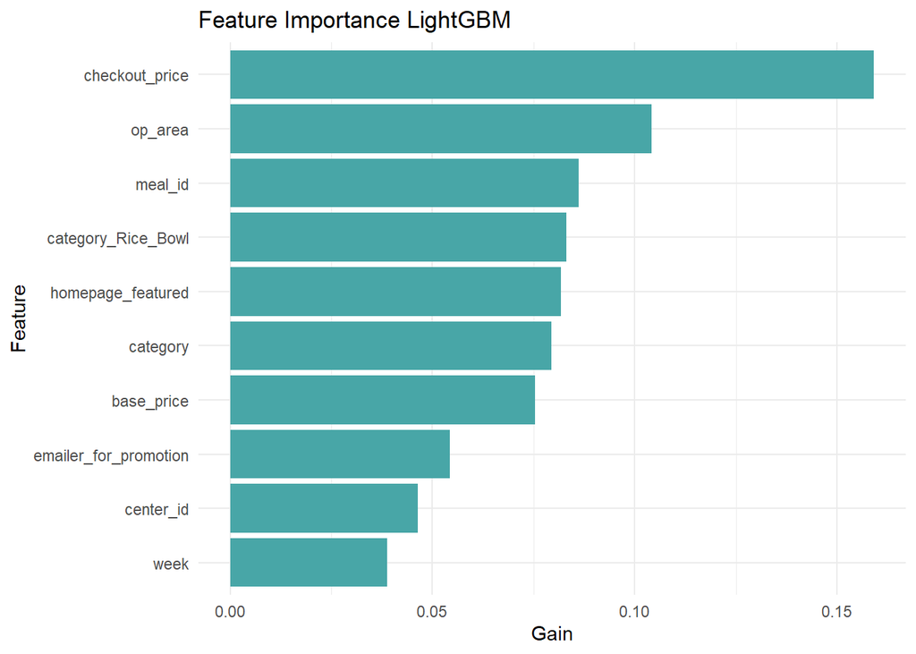

```r
# Import feature importance
importance_lgb <- lgb.importance(model_lgb, percentage = TRUE)

# Konversi ke dataframe untuk plotting manual
importance_lgb$Feature <- factor(importance_lgb$Feature, levels = rev(importance_lgb$Feature))

# Plot dengan ggplot2 dan warna kustom
ggplot(importance_lgb[1:10, ], aes(x = Gain, y = Feature)) +
  geom_col(fill = "#48A6A7") +
  labs(title = "Feature Importance LightGBM", x = "Gain", y = "Feature") +
  theme_minimal()
```

### 2. XGBoost

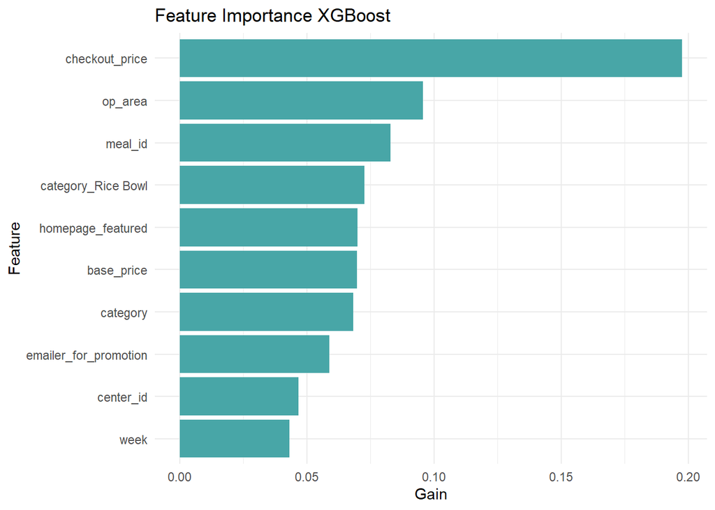

```r
# Mendapatkan feature importance
importance_xgb <- xgb.importance(feature_names = colnames(X_train_final), model = model_xgb)

# Konversi ke dataframe untuk plotting manual
importance_xgb$Feature <- factor(importance_xgb$Feature, levels = rev(importance_xgb$Feature))

# Plot dengan ggplot2 dan warna kustom
ggplot(importance_xgb[1:10, ], aes(x = Gain, y = Feature)) +
  geom_col(fill = "#48A6A7") +
  labs(title = "Feature Importance XGBoost", x = "Gain", y = "Feature") +
  theme_minimal()
```

### 3. Random Forest

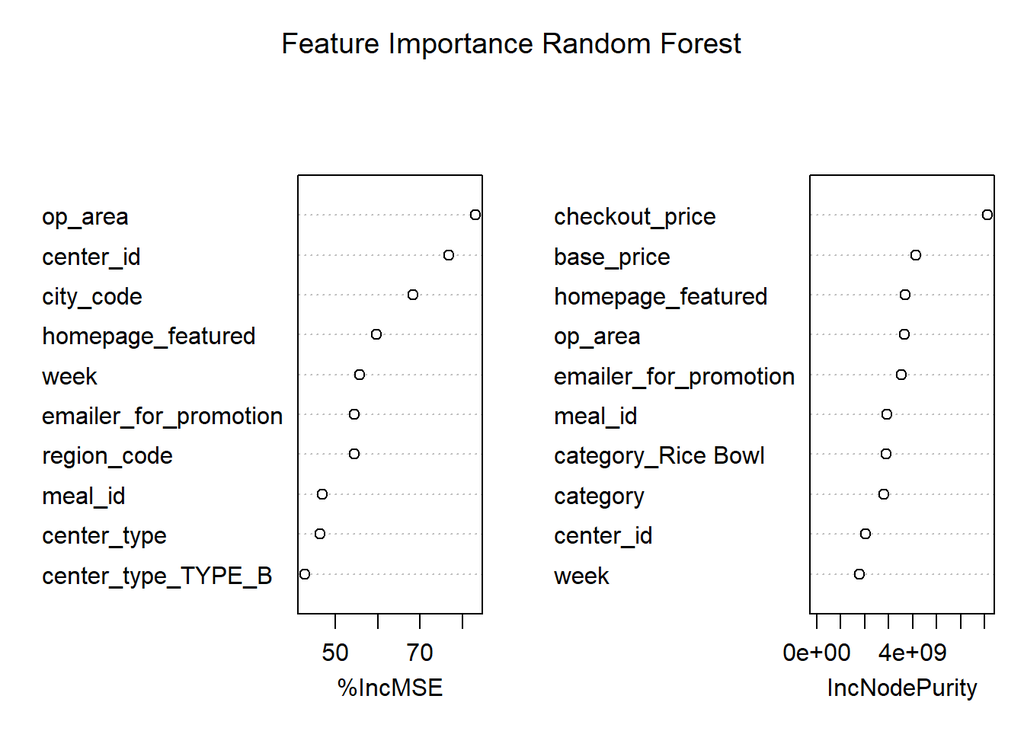

```r
### Feature Importance untuk Random Forest
importance_rf <- importance(model_rf)
varImpPlot(model_rf, n.var = 10, main = "Feature Importance Random Forest")
```

Berdasarkan grafik feature importance dari model Random Forest, ada dua metrik utama yang digunakan, yaitu %IncMSE (**peningkatan Mean Squared Error jika fitur diacak**) dan IncNodePurity (**peningkatan purity node dalam pohon keputusan**).

## Prediction

### Pre-Processing Data

Data Testing dilakukan pre-processing data seperti yang sebelumnya sudah dilakukan pada data training untuk membangkit model. Hal ini dilakukan untuk **memastikan konsistensi antara data training dan testing** sehingga model yang telah dilatih pada data training dapat memproses data testing dengan karakteristik yang serupa.

```r
test <- test %>%
  left_join(meal_info, by = "meal_id")

head(test)
```

```
# A tibble: 6 × 10
      id  week center_id meal_id checkout_price base_price emailer_for_promotion
   <dbl> <dbl>     <dbl>   <dbl>          <dbl>      <dbl>                 <dbl>
1 1.02e6   136        55    1885          148.        148.                     0
2 1.40e6   136        55    1993          151.        151.                     0
3 1.01e6   136        55    2539          152.        151.                     0
4 1.04e6   136        55    2631           96.0       166.                     0
5 1.02e6   136        55    1248           97         166.                     0
6 1.19e6   136        55    1778          165.        165.                     0
# ℹ 3 more variables: homepage_featured <dbl>, category <chr>, cuisine <chr>
```

```r
test <- test %>%
  left_join(fulfilment_center_info, by = "center_id")

head(test)
```

```
# A tibble: 6 × 14
      id  week center_id meal_id checkout_price base_price emailer_for_promotion
   <dbl> <dbl>     <dbl>   <dbl>          <dbl>      <dbl>                 <dbl>
1 1.02e6   136        55    1885          148.        148.                     0
2 1.40e6   136        55    1993          151.        151.                     0
3 1.01e6   136        55    2539          152.        151.                     0
4 1.04e6   136        55    2631           96.0       166.                     0
5 1.02e6   136        55    1248           97         166.                     0
6 1.19e6   136        55    1778          165.        165.                     0
# ℹ 7 more variables: homepage_featured <dbl>, category <chr>, cuisine <chr>,
#   city_code <int>, region_code <int>, center_type <chr>, op_area <dbl>
```

```r
str(test)
```

```
tibble [32,821 × 14] (S3: tbl_df/tbl/data.frame)
 $ id                   : num [1:32821] 1017495 1395634 1007493 1042952 1022147 ...
 $ week                 : num [1:32821] 136 136 136 136 136 136 136 136 136 136 ...
 $ center_id            : num [1:32821] 55 55 55 55 55 55 55 55 55 55 ...
 $ meal_id              : num [1:32821] 1885 1993 2539 2631 1248 ...
 $ checkout_price       : num [1:32821] 148 151 152 96 97 ...
 $ base_price           : num [1:32821] 148 151 151 166 166 ...
 $ emailer_for_promotion: num [1:32821] 0 0 0 0 0 0 0 0 0 0 ...
 $ homepage_featured    : num [1:32821] 0 0 0 0 0 0 0 0 1 0 ...
 $ category             : chr [1:32821] "Beverages" "Beverages" "Beverages" "Beverages" ...
 $ cuisine              : chr [1:32821] "Thai" "Thai" "Thai" "Indian" ...
 $ city_code            : int [1:32821] 647 647 647 647 647 647 647 647 647 647 ...
 $ region_code          : int [1:32821] 56 56 56 56 56 56 56 56 56 56 ...
 $ center_type          : chr [1:32821] "TYPE_C" "TYPE_C" "TYPE_C" "TYPE_C" ...
 $ op_area              : num [1:32821] 2 2 2 2 2 2 2 2 2 2 ...
```

```r
# Memastikan X_train dan X_test adalah data.table
setDT(test)

# Identifikasi fitur kategorikal yang valid
categorical_features <- names(test)[sapply(test, is.character)]
categorical_features <- intersect(names(test), categorical_features)

# Konversi fitur kategorikal menjadi faktor
test[, (categorical_features) := lapply(.SD, as.factor), .SDcols = categorical_features]

# Pastikan categorical_features hanya berisi fitur yang ada di X_train_final
setdiff(categorical_features, names(test))  # Harusnya output kosong
```

```
character(0)
```

```r
# One-Hot Encoding untuk fitur kategorikal pada X_train dan X_test
test_encoded <- dummy_cols(test, select_columns = categorical_features, remove_first_dummy = TRUE)

# Pastikan semua kolom dalam data adalah numerik setelah encoding
test_final <-test_encoded %>%
  select(-id)

test_final <- data.matrix(test_final)
head(test_final)
```

```
     week center_id meal_id checkout_price base_price emailer_for_promotion
[1,]  136        55    1885         148.44     148.44                     0
[2,]  136        55    1993         151.38     151.38                     0
[3,]  136        55    2539         152.35     151.35                     0
[4,]  136        55    2631          96.03     165.93                     0
[5,]  136        55    1248          97.00     165.93                     0
[6,]  136        55    1778         164.90     164.90                     0
     homepage_featured category cuisine city_code region_code center_type
[1,]                 0        1       4       647          56           3
[2,]                 0        1       4       647          56           3
[3,]                 0        1       4       647          56           3
[4,]                 0        1       2       647          56           3
[5,]                 0        1       2       647          56           3
[6,]                 0        1       3       647          56           3
     op_area category_Biryani category_Desert category_Extras category_Fish
```

[output cut: 34 more lines]

```r
# Konfirmasi bahwa tidak ada NA di data
sum(is.na(test_final))  # Harusnya 0
```

```
[1] 0
```

Data pada minggu ke-136 sampai minggu ke-145 yang sudah ada dalam data training sebelumnya akan digunakan sebagai validasi dari hasil prediksi `num_orders`.

```r
y_test <- test_validation$num_orders
```

### Stacking

Metode stacking dengan **Gradient Boosting Machine (GBM) sebagai meta-model** akan dilakukan untuk prediksi karena memiliki performa terbaik dibandingkan dengan model-model lainnya.

```r
stack_test <- data.frame(
  y_test,
  preds_lgb = predict(model_lgb, as.matrix(test_final)),
  preds_xgb = predict(model_xgb, as.matrix(test_final)),
  preds_rf  = predict(model_rf, test_final)
)
```

```r
# Prediksi menggunakan meta-model
preds_stack <- predict(meta_model, stack_test)

# Menghitung RMSE
rmse <- sqrt(mean((preds_stack - y_test)^2))
cat("Root Mean Squared Error (RMSE):", rmse, "\n")
```

```
Root Mean Squared Error (RMSE): 123.5809
```

```r
# Menghitung R-squared (R²)
sst <- sum((y_test - mean(y_test))^2)
sse <- sum((y_test - preds_stack)^2)
r2_stack <- 1 - (sse / sst)
cat("R-squared (R²):", r2_stack, "\n")
```

```
R-squared (R²): 0.8003736
```

Hasil prediksi menggunakan metode stacking dengan Gradient Boosting Machine (GBM) sebagai meta-model menunjukkan performa yang cukup baik. Nilai Root Mean Squared Error (RMSE) sebesar 123.58 menunjukkan bahwa rata-rata kesalahan prediksi model terhadap nilai aktual berada dalam kisaran tersebut. Sementara itu, nilai **R-squared (R²) sebesar 0.8004 mengindikasikan bahwa model dapat menjelaskan sekitar 80.04% variasi dalam validasi hasil prediksi.** Ini menunjukkan bahwa pendekatan stacking berhasil menggabungkan keunggulan dari model LightGBM, XGBoost, dan Random Forest untuk meningkatkan akurasi prediksi dibandingkan dengan model individu. Namun, masih terdapat sekitar 19.96% variasi yang tidak dapat dijelaskan oleh model, yang bisa menjadi **peluang untuk perbaikan lebih lanjut, misalnya dengan melakukan tuning hyperparameter atau menambahkan fitur tambahan.**